# Project3

## **Project 3 - Supervised learning:Classification**

### **Title**: *Personal Loan Campaign*

### **Author**: *Pankaj Singh*

**Domain**

Market analytics/Loan Risk

**Project Context**

AllLife Bank is a US bank that has a growing customer base. The majority of these customers are liability customers (depositors) with varying sizes of deposits. The number of customers who are also borrowers (asset customers) is quite small, and the bank is interested in expanding this base rapidly to bring in more loan business and in the process, earn more through the interest on loans. In particular, the management wants to explore ways of converting its liability customers to personal loan customers (while retaining them as depositors).

A campaign that the bank ran last year for liability customers showed a healthy conversion rate of over 9% success. This has encouraged the retail marketing department to devise campaigns with better target marketing to increase the success ratio.

You as a Data scientist at AllLife bank have to build a model that will help the marketing department to identify the potential customers who have a higher probability of purchasing the loan.

**Data Description**

The data contains the different attributes of bank customers and if they accepted the request for personal loan.

**Attribute Information**

- **`ID`** : Customer ID
- **`Age`** : Customer’s age in completed years
- **`Experience`** : Number of years of professional experience
- **`Income`** : Annual income of the customer (in thousand dollars)
- **`ZIP Code`** : Home Address ZIP code
- **`Family`** : The Family size of the customer
- **`CCAvg`** : Average spending on credit cards per month (in thousand dollars)
- **`Education`** : Education Level. 1: Undergrad; 2: Graduate;3: Advanced/Professional
- **`Mortgage`** : Value of house mortgage if any. (in thousand dollars)
- **`Personal_Loan`** : Did this customer accept the personal loan offered in the last campaign?
- **`Securities_Account`** : Does the customer have securities account with the bank?
- **`CD_Account`** : Does the customer have a certificate of deposit (CD) account with the bank?
- **`Online`** : Do customers use internet banking facilities?
- **`CreditCard`** : Does the customer use a credit card issued by any other Bank (excluding All life Bank)

**Project Deliverables**

- To predict whether a liability customer will buy a personal loan or not.
- Which variables are most significant.
- Which segment of customers should be targeted more.

**Learning Objective**

- Exploratory Data Analysis and insights
- Data pre-processing
- Logistic regression : Model building, evaluation \& improvement
- Decision Tree : Model building, evaluation \& improvement

## 1. **Import Libraries**

```python
# this will help in making the Python code more structured automatically (good coding practice)
%load_ext nb_black

import warnings

warnings.filterwarnings("ignore")

# Libraries to help with reading and manipulating data

import pandas as pd
import numpy as np

# Library to split data
from sklearn.model_selection import train_test_split

# libaries to help with data visualization
import matplotlib.pyplot as plt
import seaborn as sns

# Removes the limit for the number of displayed columns
pd.set_option("display.max_columns", None)
# Sets the limit for the number of displayed rows
pd.set_option("display.max_rows", 200)

# To build model for prediction

from sklearn.linear_model import LogisticRegression

# Libraries to build decision tree classifier
from sklearn.tree import DecisionTreeClassifier
from sklearn import tree

# To tune different models
from sklearn.model_selection import GridSearchCV

# To get diferent metric scores

from sklearn.metrics import (
    f1_score,
    accuracy_score,
    recall_score,
    precision_score,
    confusion_matrix,
    roc_auc_score,
    plot_confusion_matrix,
    precision_recall_curve,
    roc_curve,
    make_scorer,
)

# Import zipcode parser
import zipcodes as zc
```

## 2. **Load data \& get a first glimpse**

```python
# Load data from csv file
data = pd.read_csv("Loan_Modelling.csv")
loan = data.copy()
```

- #### Shape of the dataset

```python
## Print out the shape of the dataset
loan.shape
```

```
(5000, 14)
```

```python
## Print out the random 5 rows of the data
loan.sample(5)
```

|  | ID | Age | Experience | Income | ZIPCode | Family | CCAvg | Education | Mortgage | Personal_Loan | Securities_Account | CD_Account | Online | CreditCard |
| --- | --- | --- | --- | --- | --- | --- | --- | --- | --- | --- | --- | --- | --- | --- |
| 3286 | 3287 | 62 | 36 | 58 | 95020 | 1 | 2.8 | 2 | 0 | 0 | 0 | 0 | 0 | 1 |
| 1844 | 1845 | 65 | 40 | 21 | 92717 | 3 | 0.1 | 3 | 0 | 0 | 0 | 0 | 0 | 1 |
| 1828 | 1829 | 30 | 4 | 25 | 92123 | 2 | 0.3 | 2 | 0 | 0 | 0 | 0 | 0 | 0 |
| 2375 | 2376 | 55 | 30 | 69 | 91007 | 4 | 1.3 | 3 | 0 | 0 | 1 | 1 | 1 | 1 |
| 4566 | 4567 | 24 | 0 | 131 | 92831 | 1 | 5.4 | 1 | 0 | 0 | 0 | 0 | 1 | 0 |

- #### Drop the redundant columns

As we can see that ID is almost similar to the automatic indexing, so we will drop the `ID` column

```python
loan.drop(["ID"], axis=1, inplace=True)
```

- #### Formatting ZipCode information into Regions

```
94720    169
94305    127
95616    116
90095     71
93106     57
        ...
96145      1
94087      1
91024      1
93077      1
94598      1
Name: ZIPCode, Length: 467, dtype: int64
```

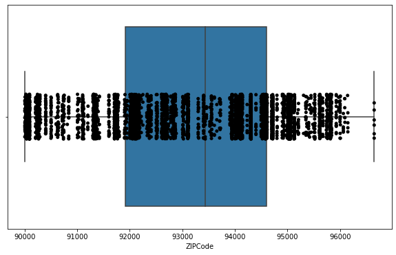

```python
# Plotting the distribution of ZipCodes using stripplot over boxplot
fig, ax = plt.subplots(nrows=1, ncols=1, figsize=(10, 6))
sns.stripplot(loan["ZIPCode"], ax=ax, color="k")
sns.boxplot(loan["ZIPCode"], ax=ax)

# Taking a peek at the number of unique ZipCodes in the dataset
loan["ZIPCode"].value_counts()
```

```python
print(
    "First five Zip Codes : ",
    loan["ZIPCode"].value_counts().index.sort_values().to_list()[:5],
)

print(
    "Last five Zip Codes : ",
    loan["ZIPCode"].value_counts().index.sort_values().to_list()[-5:],
)
```

```
First five Zip Codes :  [90005, 90007, 90009, 90011, 90016]
Last five Zip Codes :  [96091, 96094, 96145, 96150, 96651]
```

- There are 467 unique Zip Codes in the dataset.
- Based on the box and strip plots of Zip Codes, we can see that range complies with [California Zip Codes](http://www.structnet.com/instructions/zip_min_max_by_state.html)
  - This is also eveident from the first 5 and last 5 values of Zip Codes from the sorted Zip Codes list
  - Except the last Zip Code which is out of this range. We will manually assing it to a region based on google search

```python
## Assign all the unique values of Zip Codes to an array
ZIPCodes = loan["ZIPCode"].value_counts().index.to_numpy()

## Create a dictionary to store the Zip Code and corresponding county to a dictionary
ZIPCodes_to_county = {}

## Hand code the missing county data for following Zip Codes
missing_ZIPCodes = {
    "96651": "San Francisco",  # Source: http://www.placesnamed.com/f/_/f_p_o_96651.asp
    "92634": "Orange",  # Source: https://uszipcodesbystate.com/zip/92634
    "93077": "Ventura",  # Source: http://www.ciclt.net/sn/clt/capitolimpact/gw_ziplist.aspx?ClientCode=capitolimpact&State=ca&StName=&StFIPS=&FIPS=06111
    "92717": "Orange",  # Source: https://uszipcodesbystate.com/zip/92717
}

## Run the code over the list of Zip Codes and assign them a county
for ZIPCode in ZIPCodes:
    ZIPinfo = zc.matching(str(ZIPCode))
    if len(ZIPinfo) == 1:
        county = ZIPinfo[0]["county"].replace(" County", "")
    else:
        county = missing_ZIPCodes[str(ZIPCode)]

    ZIPCodes_to_county.update({ZIPCode: county})

## Show the list of all unique county names
list(set(ZIPCodes_to_county.values()))
```

```
['Marin',
 'San Mateo',
 'Yolo',
 'Stanislaus',
 'Kern',
 'San Francisco',
 'Tuolumne',
 'Lake',
 'Santa Cruz',
 'Napa',
 'Riverside',
 'El Dorado',
 'Humboldt',
 'Shasta',
 'Fresno',
 'San Diego',
 'Mendocino',
 'Solano',
 'Sacramento',
 'San Bernardino',
 'Butte',
 'Monterey',
 'Orange',
 'San Benito',
 'Merced',
 'Imperial',
 'Trinity',
 'Ventura',
 'Santa Barbara',
 'Santa Clara',
 'Los Angeles',
 'Placer',
 'Sonoma',
 'San Luis Obispo',
 'Contra Costa',
 'Alameda',
 'San Joaquin',
 'Siskiyou']
```

Encoding for the region is entered below and was found at [California Census website](https://census.ca.gov/regions/)

```python
# Dictionary of county name and region code
county_to_regioncode = {
    "Alameda": 3,
    "Butte": 1,
    "Contra Costa": 3,
    "El Dorado": 1,
    "Fresno": 6,
    "Humboldt": 2,
    "Imperial": 10,
    "Kern": 6,
    "Lake": 2,
    "Los Angeles": 8,
    "Marin": 3,
    "Mendocino": 2,
    "Merced": 4,
    "Monterey": 5,
    "Napa": 2,
    "Orange": 9,
    "Placer": 1,
    "Riverside": 7,
    "Sacramento": 1,
    "San Benito": 5,
    "San Bernardino": 7,
    "San Diego": 10,
    "San Francisco": 3,
    "San Joaquin": 4,
    "San Luis Obispo": 5,
    "San Mateo": 3,
    "Santa Barbara": 5,
    "Santa Clara": 3,
    "Santa Cruz": 5,
    "Shasta": 1,
    "Siskiyou": 1,
    "Solano": 3,
    "Sonoma": 2,
    "Stanislaus": 4,
    "Trinity": 2,
    "Tuolumne": 4,
    "Ventura": 5,
    "Yolo": 1,
}

# Dictionary of region code and region name
regioncode_to_regionname = {
    "1": "Superior_California",
    "2": "North_Coast",
    "3": "San_Francisco_Bay_Area",
    "4": "San_Joaquin_Valley",
    "5": "Central_Coast",
    "6": "San_Joaquin_Valley",
    "7": "Inland_Empire",
    "8": "Los_Angeles_County",
    "9": "Orange_County",
    "10": "San_Diego-Imperial",
}

# Creating a dictionary mapping county to region name
county_to_regionname = {}
for key, value in county_to_regioncode.items():
    county_to_regionname.update({key: regioncode_to_regionname[str(value)]})

# Creating a dictionary mapping ZIPCode to region name
ZIPCode_to_regioname = {}
for key, value in ZIPCodes_to_county.items():
    ZIPCode_to_regioname.update({key: county_to_regionname[value]})
```

```python
# create a new column which maps the ZIPCode to the region
loan["Region"] = loan["ZIPCode"].map(ZIPCode_to_regioname)
loan.drop("ZIPCode", axis=1, inplace=True)
```

- #### Check the data types of the columns for the dataset

```python
loan.info()
```

```
<class 'pandas.core.frame.DataFrame'>
RangeIndex: 5000 entries, 0 to 4999
Data columns (total 13 columns):
 #   Column              Non-Null Count  Dtype
---  ------              --------------  -----
 0   Age                 5000 non-null   int64
 1   Experience          5000 non-null   int64
 2   Income              5000 non-null   int64
 3   Family              5000 non-null   int64
 4   CCAvg               5000 non-null   float64
 5   Education           5000 non-null   int64
 6   Mortgage            5000 non-null   int64
 7   Personal_Loan       5000 non-null   int64
 8   Securities_Account  5000 non-null   int64
 9   CD_Account          5000 non-null   int64
 10  Online              5000 non-null   int64
 11  CreditCard          5000 non-null   int64
 12  Region              5000 non-null   object
dtypes: float64(1), int64(11), object(1)
memory usage: 507.9+ KB
```

- After a quick look we can see that there are no apparent missing values in the dataset
- We will convert all the column names to lower case

```python
# converting all the column names to lower case for convenience
loan.columns = [col.lower() for col in loan.columns]
print(loan.columns)
```

```
Index(['age', 'experience', 'income', 'family', 'ccavg', 'education',
       'mortgage', 'personal_loan', 'securities_account', 'cd_account',
       'online', 'creditcard', 'region'],
      dtype='object')
```

## 3. **Statistical details of the dataset**

- #### Statistical description of numerical columns

```python
loan.describe().T
```

|  | count | mean | std | min | 25% | 50% | 75% | max |
| --- | --- | --- | --- | --- | --- | --- | --- | --- |
| age | 5000.0 | 45.338400 | 11.463166 | 23.0 | 35.0 | 45.0 | 55.0 | 67.0 |
| experience | 5000.0 | 20.104600 | 11.467954 | -3.0 | 10.0 | 20.0 | 30.0 | 43.0 |
| income | 5000.0 | 73.774200 | 46.033729 | 8.0 | 39.0 | 64.0 | 98.0 | 224.0 |
| family | 5000.0 | 2.396400 | 1.147663 | 1.0 | 1.0 | 2.0 | 3.0 | 4.0 |
| ccavg | 5000.0 | 1.937938 | 1.747659 | 0.0 | 0.7 | 1.5 | 2.5 | 10.0 |
| education | 5000.0 | 1.881000 | 0.839869 | 1.0 | 1.0 | 2.0 | 3.0 | 3.0 |
| mortgage | 5000.0 | 56.498800 | 101.713802 | 0.0 | 0.0 | 0.0 | 101.0 | 635.0 |
| personal_loan | 5000.0 | 0.096000 | 0.294621 | 0.0 | 0.0 | 0.0 | 0.0 | 1.0 |
| securities_account | 5000.0 | 0.104400 | 0.305809 | 0.0 | 0.0 | 0.0 | 0.0 | 1.0 |
| cd_account | 5000.0 | 0.060400 | 0.238250 | 0.0 | 0.0 | 0.0 | 0.0 | 1.0 |
| online | 5000.0 | 0.596800 | 0.490589 | 0.0 | 0.0 | 1.0 | 1.0 | 1.0 |
| creditcard | 5000.0 | 0.294000 | 0.455637 | 0.0 | 0.0 | 0.0 | 1.0 | 1.0 |

```python
# function to show univariate analysis of continuous data columns
def histogram_boxplot(data, feature, figsize=(12, 7), kde=False, bins=None):
    """
    Boxplot and histogram combined

    data: dataframe
    feature: dataframe column
    figsize: size of figure (default (12,7))
    kde: whether to show the density curve (default False)
    bins: number of bins for histogram (default None)
    """
    f2, (ax_box2, ax_hist2) = plt.subplots(
        nrows=2,  # Number of rows of the subplot grid= 2
        sharex=True,  # x-axis will be shared among all subplots
        gridspec_kw={"height_ratios": (0.25, 0.75)},
        figsize=figsize,
    )  # creating the 2 subplots
    sns.boxplot(
        data=data, x=feature, ax=ax_box2, showmeans=True, color="violet"
    )  # boxplot will be created and a star will indicate the mean value of the column
    sns.histplot(
        data=data, x=feature, kde=kde, ax=ax_hist2, bins=bins, palette="winter"
    ) if bins else sns.histplot(
        data=data, x=feature, kde=kde, ax=ax_hist2
    )  # For histogram
    ax_hist2.axvline(
        data[feature].mean(), color="green", linestyle="--"
    )  # Add mean to the histogram
    ax_hist2.axvline(
        data[feature].median(), color="black", linestyle="-"
    )  # Add median to the histogram

    # Print the statistical distirbution of the numerical variable
    print(data[feature].describe())
```

```python
# function to create labeled barplots for categorical data
def labeled_barplot(data, feature, perc=False, n=None):
    """
    Barplot with percentage at the top

    data: dataframe
    feature: dataframe column
    perc: whether to display percentages instead of count (default is False)
    n: displays the top n category levels (default is None, i.e., display all levels)
    """

    total = len(data[feature])  # length of the column
    count = data[feature].nunique()
    if n is None:
        plt.figure(figsize=(count + 1, 5))
    else:
        plt.figure(figsize=(n + 1, 5))

    plt.xticks(rotation=90, fontsize=15)
    ax = sns.countplot(
        data=data,
        x=feature,
        palette="Paired",
        order=data[feature].value_counts().index[:n].sort_values(),
    )

    for p in ax.patches:
        if perc == True:
            label = "{:.1f}%".format(
                100 * p.get_height() / total
            )  # percentage of each class of the category
        else:
            label = p.get_height()  # count of each level of the category

        x = p.get_x() + p.get_width() / 2  # width of the plot
        y = p.get_height()  # height of the plot

        ax.annotate(
            label,
            (x, y),
            ha="center",
            va="center",
            size=12,
            xytext=(0, 5),
            textcoords="offset points",
        )  # annotate the percentage

    plt.show()  # show the plot
```

- #### Observations on Age

```
count    5000.000000
mean       45.338400
std        11.463166
min        23.000000
25%        35.000000
50%        45.000000
75%        55.000000
max        67.000000
Name: age, dtype: float64
```

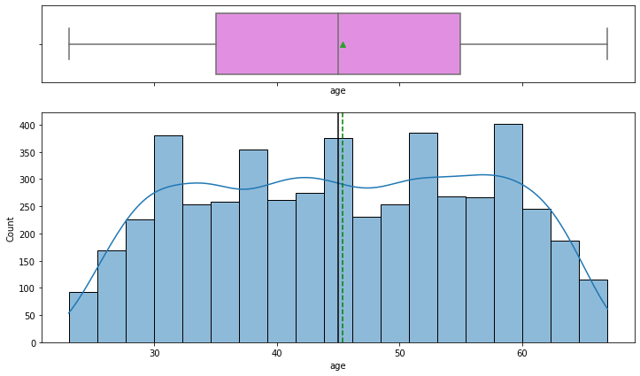

```python
histogram_boxplot(loan, "age", figsize=(12, 7), kde=True, bins=None)
```

```python
# introducing age groups based on decades of ages
loan["ageGroup"] = pd.cut(
    loan["age"],
    bins=[20, 30, 40, 50, 60, 70],
    labels=["21-30", "31-40", "41-50", "51-60", "61-70"],
)
```

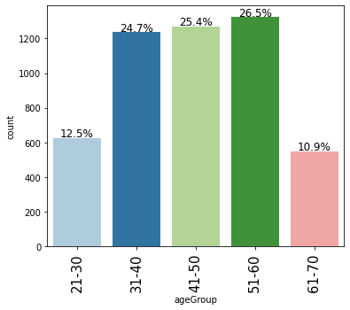

```python
# Visual on age group distributions
labeled_barplot(loan, "ageGroup", perc=True)
```

- The distribution of age looks very symmetric and almost like a uniform distribution
- The youngest person in the dataset is 23 years old and oldest is 67
- The mean and median values of the age data are almost equal
- We created 5 age groups based on decades and we can see that the majority customer are in the 31-60 age group
- The rest of terminal age groups (21-30 \& 61-70) account for ~24% customers
- The age dataset looks good and ready for analysis
- #### Observations on Experience

```
count    5000.000000
mean       20.104600
std        11.467954
min        -3.000000
25%        10.000000
50%        20.000000
75%        30.000000
max        43.000000
Name: experience, dtype: float64
```

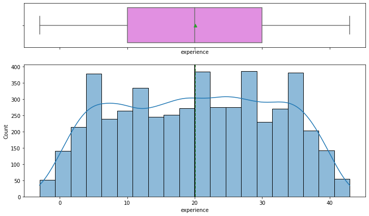

```python
histogram_boxplot(loan, "experience", figsize=(12, 7), kde=True, bins=None)
```

```python
loan.corr()["experience"].sort_values()
```

```
family               -0.052563
ccavg                -0.050077
income               -0.046574
mortgage             -0.010582
personal_loan        -0.007413
securities_account   -0.001232
creditcard            0.008967
cd_account            0.010353
education             0.013152
online                0.013898
age                   0.994215
experience            1.000000
Name: experience, dtype: float64
```

As we can see from the correlation, that experience and age are very strongly correlated with each other. So we will use this information to fill the median values with corresponding median for that age.

- First we replace the negative values with NaNs

```python
loan["experience"] = loan["experience"].apply(lambda x: x if x > 0 else np.nan)
```

- Get the indices of all the missing values of experience

```python
expnull = loan[loan["experience"].isnull()].index
loan.iloc[expnull, :]["age"].value_counts()
```

```
25    35
26    29
24    28
23    12
27     8
29     4
28     1
30     1
Name: age, dtype: int64
```

- Get ages cooresponding to the missing experience values

```python
age_for_expnull = (
    loan.iloc[expnull, :]["age"].value_counts().index.sort_values().to_list()
)
```

- Let's check how many data entries are there corresponding to ages which had experience missing

```python
loan[loan["age"].isin(age_for_expnull)].groupby("age")["experience"].agg(
    ["count", "median", "mean"]
)
```

| age | count | median | mean |
| --- | --- | --- | --- |
| 23 | 0 | NaN | NaN |
| 24 | 0 | NaN | NaN |
| 25 | 18 | 1.0 | 1.000000 |
| 26 | 49 | 2.0 | 1.551020 |
| 27 | 83 | 2.0 | 2.108434 |
| 28 | 102 | 3.0 | 3.009804 |
| 29 | 119 | 4.0 | 3.865546 |
| 30 | 135 | 5.0 | 4.896296 |

- As we can see that ages 23 and 24 have same number of data entries as in the missing entries of experience. Which means, if we replace the missing values based on the median experience years corresponding to an age, we won't fill values for ages 23 and 24, so we will fill them with zeros

```python
loan["experience"] = loan.groupby(["age"])["experience"].transform(
    lambda x: x.fillna(0 if np.isnan(x.median()) else x.median())
)
```

- Let's check the values of the missing data in experience

```python
loan[loan["age"].isin(age_for_expnull)].groupby("age")["experience"].agg(
    ["count", "median", "mean"]
)
```

| age | count | median | mean |
| --- | --- | --- | --- |
| 23 | 12 | 0.0 | 0.000000 |
| 24 | 28 | 0.0 | 0.000000 |
| 25 | 53 | 1.0 | 1.000000 |
| 26 | 78 | 2.0 | 1.717949 |
| 27 | 91 | 2.0 | 2.098901 |
| 28 | 103 | 3.0 | 3.009709 |
| 29 | 123 | 4.0 | 3.869919 |
| 30 | 136 | 5.0 | 4.897059 |

```python
loan["experience"].info()
```

```
<class 'pandas.core.series.Series'>
RangeIndex: 5000 entries, 0 to 4999
Series name: experience
Non-Null Count  Dtype
--------------  -----
5000 non-null   float64
dtypes: float64(1)
memory usage: 39.2 KB
```

- Hence we have replaced the negative values in experience with either median corresponding to the age or with zeros.

```
count    5000.000000
mean       20.146200
std        11.396034
min         0.000000
25%        10.000000
50%        20.000000
75%        30.000000
max        43.000000
Name: experience, dtype: float64
```

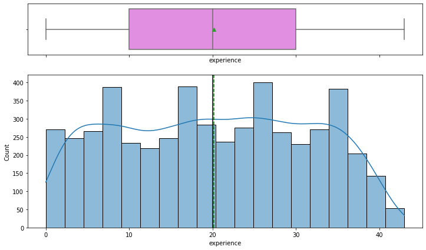

```python
histogram_boxplot(loan, "experience", figsize=(12, 7), kde=True, bins=None)
```

- The distribution of experience looks almost symmetric and almost like a uniform distribution.
- The least experienced person in the dataset has 0 years of experience and most experienced person has 43 years of experience
- The mean and median values of the age data are almost equal
- The experience dataset looks good and ready for analysis
- #### Observations on Income

```
count    5000.000000
mean       73.774200
std        46.033729
min         8.000000
25%        39.000000
50%        64.000000
75%        98.000000
max       224.000000
Name: income, dtype: float64
```

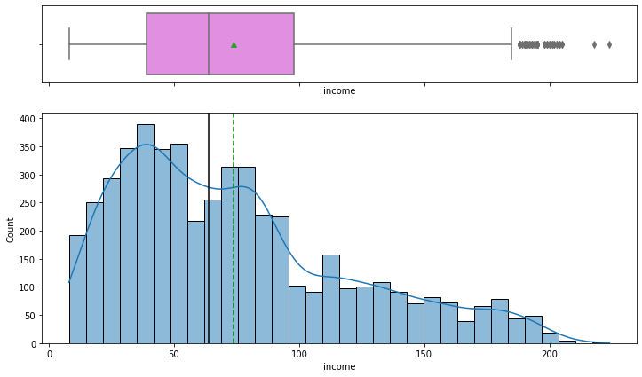

```python
histogram_boxplot(loan, "income", figsize=(12, 7), kde=True, bins=None)
```

```python
# split the income groups into three categories based on 33 percentile and 66 percentile
loan["incomeGroup"] = pd.cut(
    loan["income"],
    bins=np.quantile(loan["income"], q=[0, 0.33, 0.66, 1]),
    labels=["low", "medium", "high"],
)
```

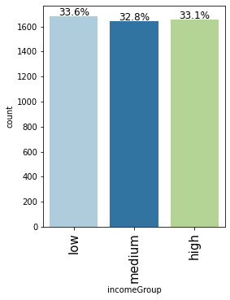

```python
# Get a visual on the income group information
labeled_barplot(loan, "incomeGroup", perc=True)
```

- The distribution of income looks almost right skewed and has many outliers on the right end
- The least income of a person in the dataset has 8k and highest income is 224k
- The mean is greater than the median value of the income data indicating a right skew in data
- When income is split into 3 classes based on the 33 percentile and 66 percentile, we can get low, medium and high income groups
- The income dataset looks good and ready for analysis
- #### Observations on Credit Card Usage

```
count    5000.000000
mean        1.937938
std         1.747659
min         0.000000
25%         0.700000
50%         1.500000
75%         2.500000
max        10.000000
Name: ccavg, dtype: float64
```

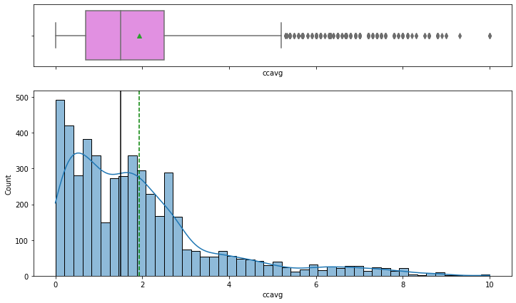

```python
histogram_boxplot(loan, "ccavg", figsize=(12, 7), kde=True, bins=None)
```

```python
# split the spending groups into three categories based on 33 percentile and 66 percentile
loan["spendingGroup"] = pd.cut(
    loan["ccavg"],
    bins=np.quantile(loan["ccavg"], q=[0, 0.33, 0.66, 1]),
    labels=["low", "medium", "high"],
)
```

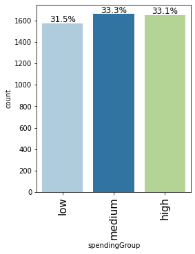

```python
# Get a visual on the spending group information
labeled_barplot(loan, "spendingGroup", perc=True)
```

- The distribution of credit card usage looks right skewed and has many outliers on the right end
- The least credit card usage of a person in the 0 has 8k and highest is 10k
- The mean is greater than the median value of the credit card usage data indicating a right skew in data
- When income is split into 3 classes based on the 33 percentile and 66 percentile, we can get low, medium and high spending groups
- The credit card usage dataset looks good and ready for analysis
- #### Observations on Mortgage

```
count    5000.000000
mean       56.498800
std       101.713802
min         0.000000
25%         0.000000
50%         0.000000
75%       101.000000
max       635.000000
Name: mortgage, dtype: float64
```

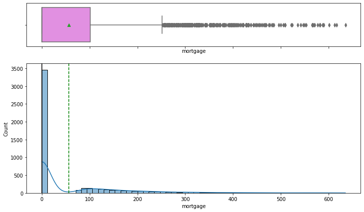

```python
histogram_boxplot(loan, "mortgage", figsize=(12, 7), kde=True, bins=None)
```

```python
# split the mortgage groups into two categories based on if they have mortgage or if they don't
loan["mortgageTaken"] = pd.cut(loan["mortgage"], bins=[-10, 10, 700], labels=[0, 1])
```

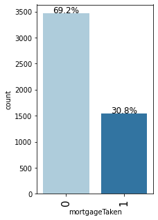

```python
labeled_barplot(loan, "mortgageTaken", perc=True)
```

- The distribution of mortgage is heavily right skewed and many outliers on the right end
- The lowest mortgage is 0k and highest is 635k
- The mean is greater than the median value of the credit card usage data indicating a right skew in data. Also, nearly 3500 people don't have any mortgage
- We have created a categorical variable based on if someone has taken any mortgage or not. Based on it, 70% of customers do not have any mortgage.
- The mortgage dataset looks good and ready for analysis
- #### Observations on family

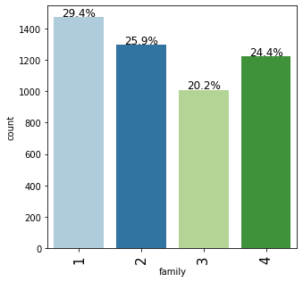

```python
labeled_barplot(loan, "family", perc=True)
```

- Here we can see that there are 4 different family sizes
- Dominant family types is one person family and least frequent family type is 3 person family
- We will encode the family data as a category

```python
loan["family"] = loan["family"].astype("category")
```

- #### Observations on education

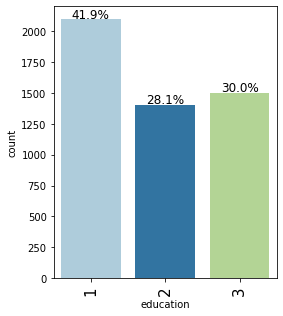

```python
labeled_barplot(loan, "education", perc=True)
```

- Here we can see that there are 3 different education levels
- Dominant education level is undergraduate and least commonn education level is graduate degree
- We will encode the education data as a category

```python
loan["education"] = loan["education"].astype("category")
```

- #### Observations on region

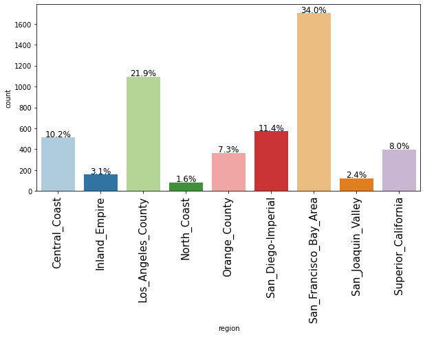

```python
labeled_barplot(loan, "region", perc=True)
```

```python
loan["region"] = loan["region"].astype("category")
```

- #### Observations on Securities account

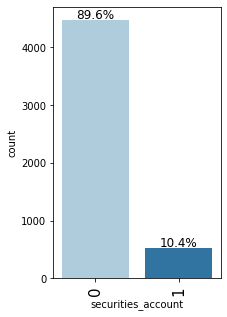

```python
labeled_barplot(loan, "securities_account", perc=True)
```

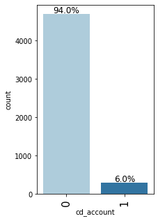

```python
labeled_barplot(loan, "cd_account", perc=True)
```

- Only 6% of the customers have CD account
- #### Observations on Online banking account

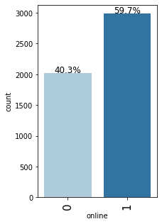

```python
labeled_barplot(loan, "online", perc=True)
```

- 60% of the customers have an online banking account.
- #### Observations on Credit card ownership

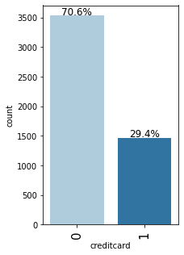

```python
labeled_barplot(loan, "creditcard", perc=True)
```

- Only 30% of the customers have a credit card.
- ### Multi-Variate Analysis

```python
# function to plot stacked bar chart
def stacked_barplot(data, predictor, target):
    """
    Print the category counts and plot a stacked bar chart

    data: dataframe
    predictor: independent variable
    target: target variable
    """
    count = data[predictor].nunique()
    sorter = data[target].value_counts().index[-1]
    tab1 = pd.crosstab(data[predictor], data[target], margins=True).sort_values(
        by=sorter, ascending=False
    )
    print(tab1)
    print("-" * 120)
    tab = pd.crosstab(data[predictor], data[target], normalize="index").sort_values(
        by=sorter, ascending=False
    )
    tab.plot(kind="bar", stacked=True, figsize=(count + 5, 6))
    plt.legend(
        loc="lower left", frameon=False,
    )
    plt.legend(loc="upper left", bbox_to_anchor=(1, 1))
    plt.show()
```

- #### Loan acceptance with region

```
personal_loan              0    1   All
region
All                     4520  480  5000
San_Francisco_Bay_Area  1535  167  1702
Los_Angeles_County       984  111  1095
San_Diego-Imperial       512   59   571
Central_Coast            462   50   512
Orange_County            333   33   366
Superior_California      368   31   399
San_Joaquin_Valley       108   11   119
Inland_Empire            148    9   157
North_Coast               70    9    79
------------------------------------------------------------------------------------------------------------------------
```

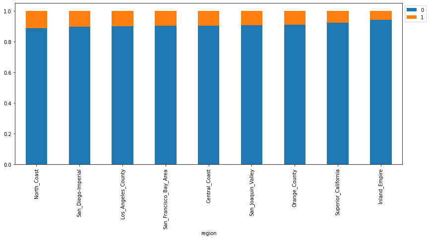

```python
stacked_barplot(loan, "region", "personal_loan")
```

- Highest number of loan campaign was turned into a actual loan to customers in the San Francisco bay area
- Among the metropolises San Diego are had the highest loan rate of loan acceptance
- Overall percentage wise, Nort Coast region had the best turnover from loan campaign to actually getting a loan
- On further investigating the source of trend in the region based loan campaign acceptance we find that spending group based classification has a correlation to it.
- The highger the proportion of low spending customers the lesser is the loan campaign acceptance

```
spendingGroup            low  medium  high   All
region
All                     1577    1664  1653  4894
San_Francisco_Bay_Area   538     559   568  1665
Los_Angeles_County       335     377   364  1076
San_Diego-Imperial       169     188   201   558
Central_Coast            163     167   171   501
Superior_California      131     134   124   389
Orange_County            127     116   118   361
Inland_Empire             47      55    47   149
San_Joaquin_Valley        44      41    33   118
North_Coast               23      27    27    77
------------------------------------------------------------------------------------------------------------------------
```

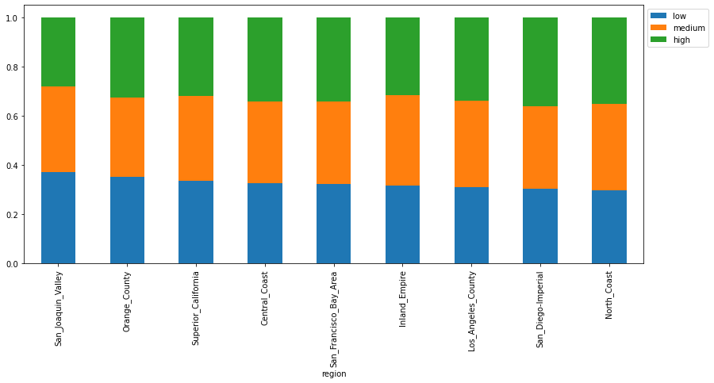

```python
stacked_barplot(loan, "region", "spendingGroup")
```

- #### Loan acceptance with income groups

```
personal_loan     0    1   All
incomeGroup
All            4497  480  4977
high           1190  464  1654
medium         1626   16  1642
low            1681    0  1681
------------------------------------------------------------------------------------------------------------------------
```

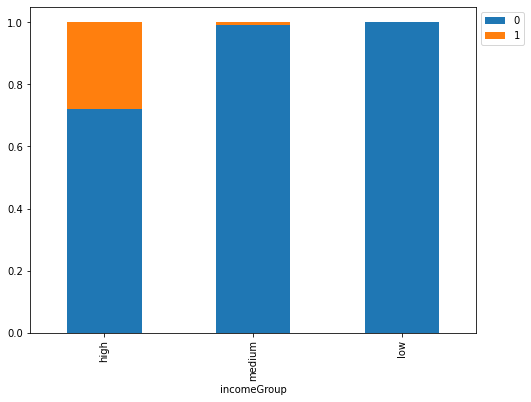

```python
stacked_barplot(loan, "incomeGroup", "personal_loan")
```

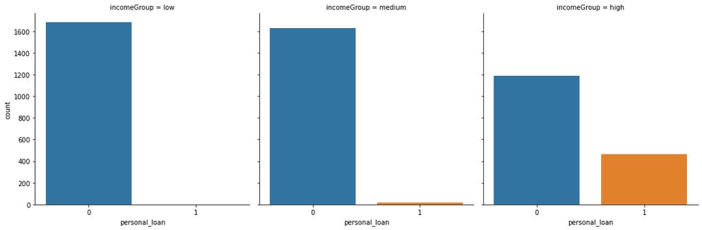

```python
sns.catplot(x="personal_loan", kind="count", col="incomeGroup", data=loan)
```

- It is clearly evident from above plots that loans campaign was accepted by the high income group, while it is really small/close to zero for medium and low income groups.
- In the following plot we visualize the income distributions in all the income categories with the hue of loan taken or not.
  - As seen before no one in the low income group took out loans
  - In the medium income group, the customers who took loan have higher median income
  - Same trend is seen for the high income group has well, the median income is higher for customers who took out loan

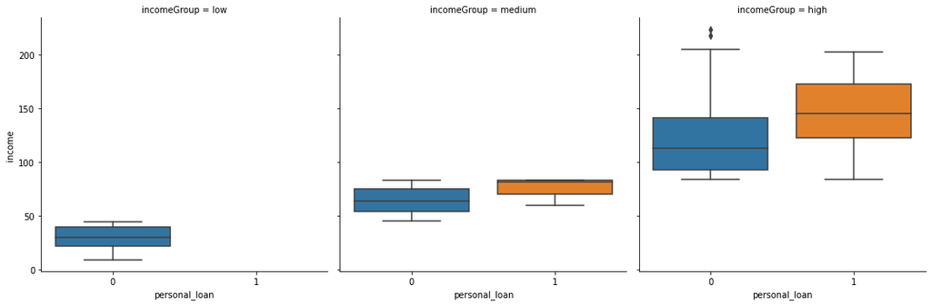

```python
sns.catplot(y="income", x="personal_loan", kind="box", col="incomeGroup", data=loan)
```

- #### Loan acceptance with age

```
personal_loan     0    1   All
ageGroup
All            4520  480  5000
41-50          1148  122  1270
31-40          1118  118  1236
51-60          1208  115  1323
21-30           558   66   624
61-70           488   59   547
------------------------------------------------------------------------------------------------------------------------
```

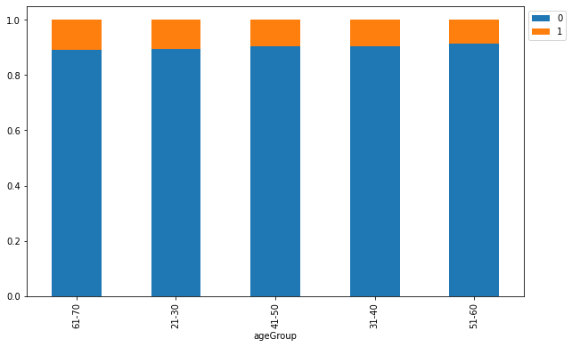

```python
stacked_barplot(loan, "ageGroup", "personal_loan")
```

- Age group based analysis of loan acceptance does not show any difference between the age groups
- This lack if differnce on the basis of age is also shown in the boxplot below, where the median age is nearly same for both groups of customer, both who accpeted loan or who did not.

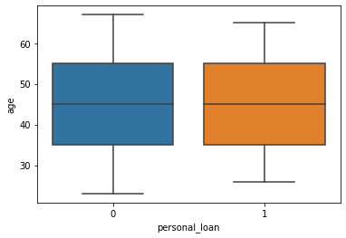

```python
sns.boxplot(data=loan, x="personal_loan", y="age")
```

- #### Loan acceptance with experience

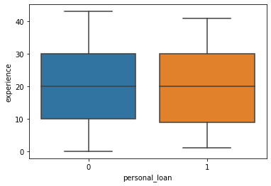

```python
sns.boxplot(data=loan, x="personal_loan", y="experience")
```

- No clear distinction could be drawn on the basis of experience on a customer tendency for taking out a loan
- #### Loan acceptance with credit card usage

```
personal_loan     0    1   All
spendingGroup
All            4415  479  4894
high           1272  381  1653
medium         1612   52  1664
low            1531   46  1577
------------------------------------------------------------------------------------------------------------------------
```

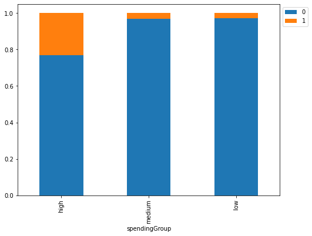

```python
stacked_barplot(loan, "spendingGroup", "personal_loan")
```

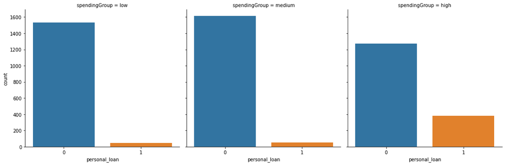

```python
sns.catplot(x="personal_loan", kind="count", col="spendingGroup", data=loan)
```

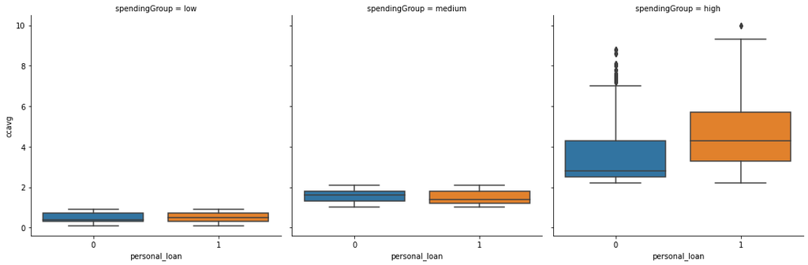

```python
sns.catplot(y="ccavg", x="personal_loan", kind="box", col="spendingGroup", data=loan)
```

- Clearly the high spending group has a higher chance of taking out a loan.
  - In the high spending group, the folks who took out loan have more spending than the folks who did not take out the loan.
- The medium and low income groups have nearly similar chances of taking out loan
  - There is not a signifcant spending difference between the folks who took out loan or didn't for both low and medium spending groups
- #### Loan acceptance with owning a credit card

```
personal_loan     0    1   All
creditcard
All            4520  480  5000
0              3193  337  3530
1              1327  143  1470
------------------------------------------------------------------------------------------------------------------------
```

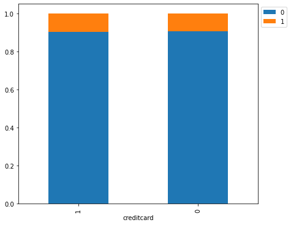

```python
stacked_barplot(loan, "creditcard", "personal_loan")
```

- No significant difference is seen in the proportions of customer on the basis of them owning a credit card and their tendency to take out loan
- #### Loan acceptance and online banking

```
personal_loan     0    1   All
online
All            4520  480  5000
1              2693  291  2984
0              1827  189  2016
------------------------------------------------------------------------------------------------------------------------
```

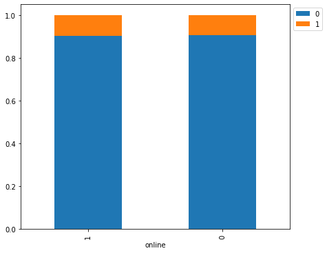

```python
stacked_barplot(loan, "online", "personal_loan")
```

- No significant difference is seen in the proportions of customer on the basis of them using an online banking and their tendency to take out loan
- #### Loan acceptance and Mortgage

```
personal_loan     0    1   All
mortgageTaken
All            4520  480  5000
0              3150  312  3462
1              1370  168  1538
------------------------------------------------------------------------------------------------------------------------
```

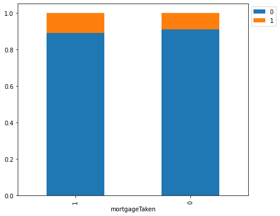

```python
stacked_barplot(loan, "mortgageTaken", "personal_loan")
```